# Analisis1

Daniel Gonzalez

2023-01-27

## Hoja de trabajo 1

### 1. Resumen del conjunto de datos.

El conjunto de datos está compuesto por 10000 filas y 27 columnas.

El resumen del conjunto de datos es el siguiente:

```
##        id             budget             genres            homePage
##  Min.   :     5   Min.   :        0   Length:10000       Length:10000
##  1st Qu.: 12286   1st Qu.:        0   Class :character   Class :character
##  Median :152558   Median :   500000   Mode  :character   Mode  :character
##  Mean   :249877   Mean   : 18551632
##  3rd Qu.:452022   3rd Qu.: 20000000
##  Max.   :922260   Max.   :380000000
##  productionCompany  productionCompanyCountry productionCountry
##  Length:10000       Length:10000             Length:10000
##  Class :character   Class :character         Class :character
##  Mode  :character   Mode  :character         Mode  :character
##
##
##
##     revenue             runtime        video           director
##  Min.   :0.000e+00   Min.   :  0.0   Mode :logical   Length:10000
##  1st Qu.:0.000e+00   1st Qu.: 90.0   FALSE:9430      Class :character
##  Median :1.631e+05   Median :100.0   TRUE :84        Mode  :character
##  Mean   :5.674e+07   Mean   :100.3   NA's :486
##  3rd Qu.:4.480e+07   3rd Qu.:113.0
##  Max.   :2.847e+09   Max.   :750.0
##     actors          actorsPopularity   actorsCharacter    originalTitle
##  Length:10000       Length:10000       Length:10000       Length:10000
##  Class :character   Class :character   Class :character   Class :character
##  Mode  :character   Mode  :character   Mode  :character   Mode  :character
##
##
##
##     title           originalLanguage     popularity        releaseDate
##  Length:10000       Length:10000       Min.   :    4.258   Length:10000
##  Class :character   Class :character   1st Qu.:   14.578   Class :character
##  Mode  :character   Mode  :character   Median :   21.906   Mode  :character
##                                        Mean   :   51.394
##                                        3rd Qu.:   40.654
##                                        Max.   :11474.647
##     voteAvg         voteCount      genresAmount    productionCoAmount
##  Min.   : 1.300   Min.   :    1   Min.   : 0.000   Min.   : 0.000
##  1st Qu.: 5.900   1st Qu.:  120   1st Qu.: 2.000   1st Qu.: 2.000
##  Median : 6.500   Median :  415   Median : 3.000   Median : 3.000
##  Mean   : 6.483   Mean   : 1342   Mean   : 2.596   Mean   : 3.171
##  3rd Qu.: 7.200   3rd Qu.: 1316   3rd Qu.: 3.000   3rd Qu.: 4.000
##  Max.   :10.000   Max.   :30788   Max.   :16.000   Max.   :89.000
##  productionCountriesAmount  actorsAmount    castWomenAmount
##  Min.   :  0.000           Min.   :     0   Length:10000
##  1st Qu.:  1.000           1st Qu.:    13   Class :character
##  Median :  1.000           Median :    21   Mode  :character
##  Mean   :  1.751           Mean   :  2148
##  3rd Qu.:  2.000           3rd Qu.:    36
##  Max.   :155.000           Max.   :919590
##  castMenAmount
##  Length:10000
##  Class :character
##  Mode  :character
##
##
##
```

### 2. Tipo de cada una de las variables de dataset.

Id: Cualitativa nominal  
Budget: Cuantitativa continua  
Genres: Cualitativa nominal  
HomePage: Cualitativa nominal  
ProductionCompany: Cualitativa nominal  
ProductionCompanyCountry: Cualitativa nominal  
ProductionCountry: Cualitativa nominal  
Revenue: Cuantitativa continua  
Runtime: Cuantitativa discreta  
Video: Cualitativa nominal  
Director: Cualitativa nominal  
Actors: Cualivativa nominal  
ActorsPopularity: Cuantitativa continua  
ActorsCharacter: Cualitativa nominal  
Title: Cualitativa nominal  
originalLanguage: Cualitativa nominal  
Popularity: Cuantitativa continua  
Release date: Cualitativa ordinal  
VoteAvg: Cuantitativa continua  
VoteCount: Cuantitativa discreta  
GenresAmount: Cuantitativa discreta  
ProductionCoAmount: Cuantitativa discreta  
ProductionCountriesAmount: Cuantitativa discreta  
ActorsAmount: Cuantitativa discreta  
CastWomenAmount: Cuantitativa discreta  
CastMenAmount: Cuantitativa discreta

## 3. Pruebas de normalidad para variables cuantitativas y tablas de

## frecuencia para variables cualitativas.

### Prueba de normalidad para **budget**.

Inicialmente se muestra un histograma de la distribución de budget.

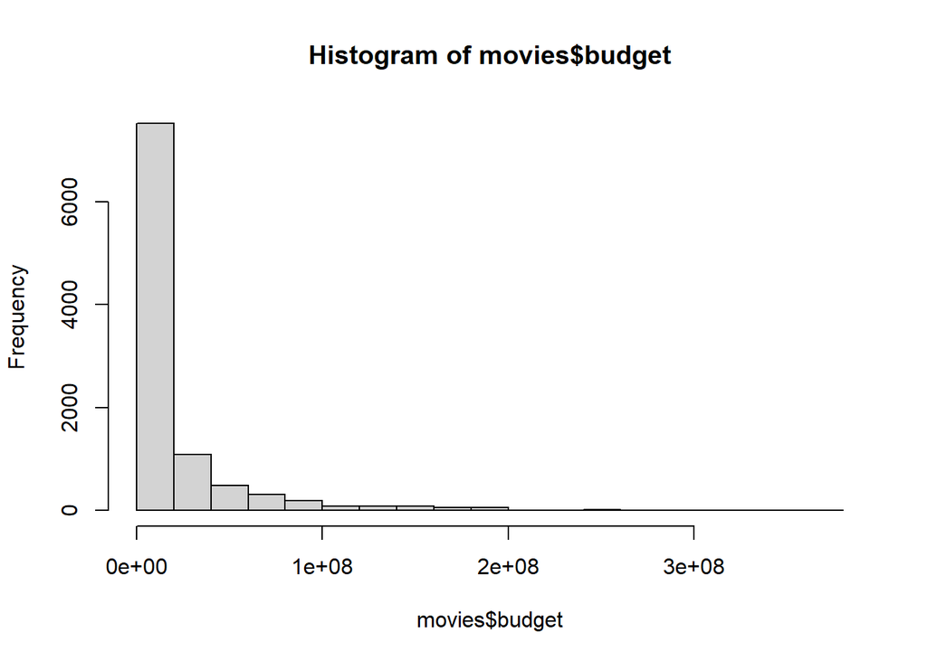

A continuación se realizó un QQplot para observar la distribución de los valores de budget.

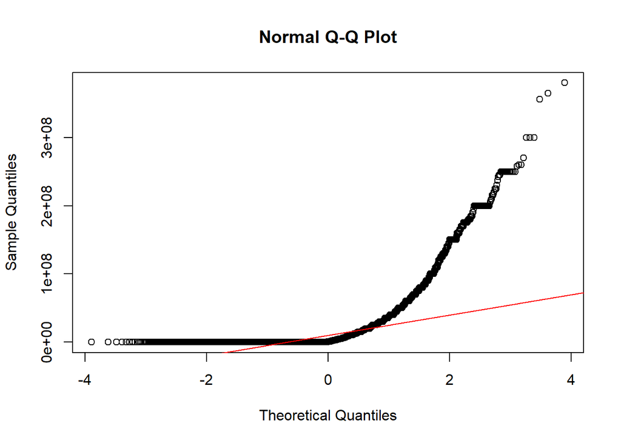

Es posible observar que la distribución de budget se aleja significativamente de la distribución teórica. Esto indica que probablemente no se tenga una distribución normal.

Para corroborar esto se realizó la prueba de normalidad de Kolmogorov-Smirnov, usando la media y desviación estándar del budget del dataset. También se realizó la prueba de normalidad de lLilliefors.

```
##
##  Asymptotic two-sample Kolmogorov-Smirnov test
##
## data:  movies$budget and rnorm(nrow(movies), mean(movies$budget), sd(movies$budget))
## D = 0.2986, p-value < 2.2e-16
## alternative hypothesis: two-sided
```

```
##
##  Lilliefors (Kolmogorov-Smirnov) normality test
##
## data:  movies$budget
## D = 0.30625, p-value < 2.2e-16
```

Como se observa en ambos resultados, el valor de p es menor que el nivel de significancia (0.05), por lo que se puede afirmar que la distribución de budget no es normal.

### Prueba de normalidad para **runtime**.

Primero se realizó un histograma para observar la distribución de la variable.

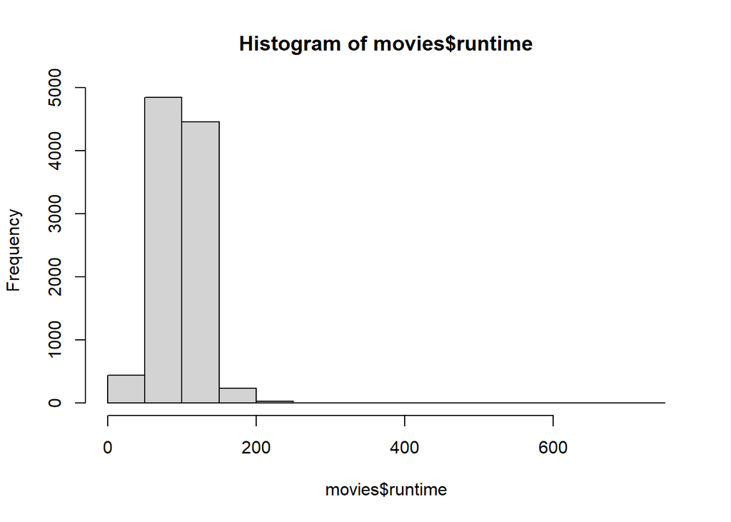

Luego se realizó un QQplot para observar la distribución de los valores de runtime.

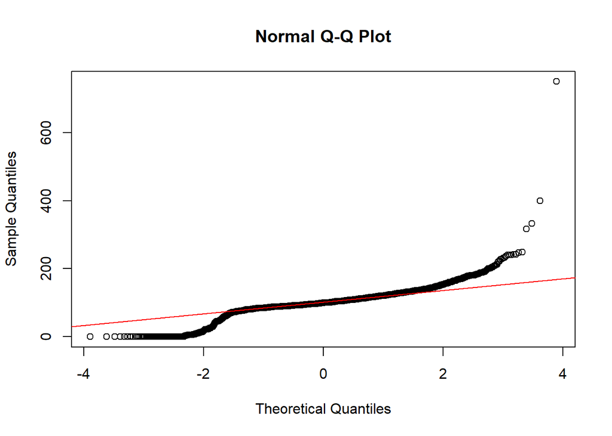

En este caso, la distribución de los datos de runtime no se aleja tanto de la distribución teórica. Los extremos de los datos son los que están más alejados de la línea teórica. Por otra parte, en el histograma anterior, se puede observar que se tiene una forma que pareciera ser normal.

Se realizó la prueba de normalidad de Kolmogorov-Smirnov, usando la media y desviación estándar de runtime del dataset. Además, se hizo una prueba de normalidad con Lilliefors.

```
##
##  Asymptotic two-sample Kolmogorov-Smirnov test
##
## data:  movies$runtime and rnorm(nrow(movies), mean(movies$runtime), sd(movies$runtime))
## D = 0.1466, p-value < 2.2e-16
## alternative hypothesis: two-sided
```

```
##
##  Lilliefors (Kolmogorov-Smirnov) normality test
##
## data:  movies$runtime
## D = 0.14408, p-value < 2.2e-16
```

Al observar los resultados de ambas pruebas, los valores de p son menores que el nivel de significancia. Por lo tanto, la distribución de runtime no es normal.

### Prueba de normalidad para **popularity**.

Se realizó un QQplot para observar la distribución de los valores de popularity.

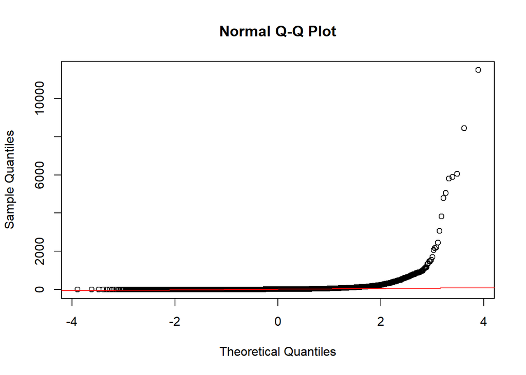

Es posible observar que la distribución de la variable sigue la distribución teórica. Sin embargo, en el extremo final, se aleja bastante de la línea.

Se realizó la prueba de normalidad de Kolmogorov-Smirnov y Lilliefors para determinar si se tiene una distribución normal.

```
##
##  Asymptotic two-sample Kolmogorov-Smirnov test
##
## data:  movies$popularity and rnorm(nrow(movies), mean(movies$popularity), sd(movies$popularity))
## D = 0.4351, p-value < 2.2e-16
## alternative hypothesis: two-sided
```

```
##
##  Lilliefors (Kolmogorov-Smirnov) normality test
##
## data:  movies$popularity
## D = 0.41734, p-value < 2.2e-16
```

Se puede determinar, debido a que el valor p es menor al nivel de significancia, que la distribución de popularity no es normal.

### Prueba de normalidad para **voteAvg**.

Se realizó un histograma para observar la distribución de la variable.

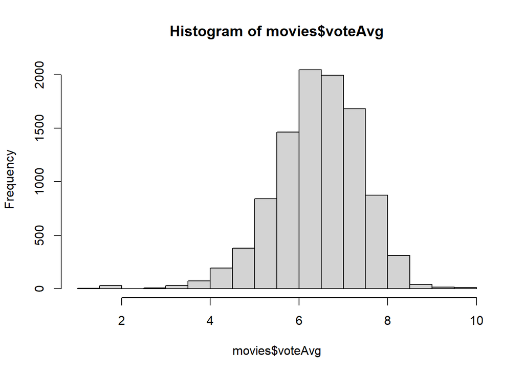

Se puede observar en el histograma que existe un sesgo a la izquierda en la distribución.

A continuación se realizó un QQplot para observar la distribución de los valores de voteAvg.

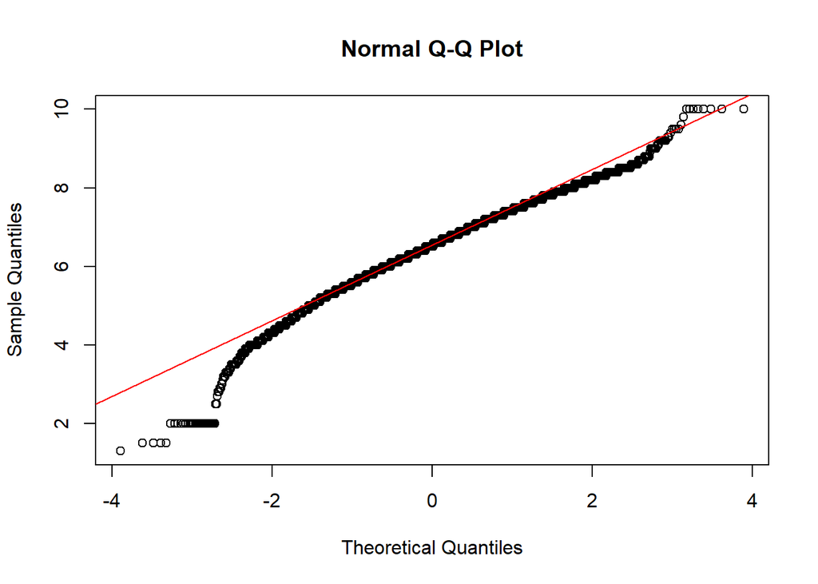

Es posible observar una diferencia con la distribución teórica en la variable, sobre todo en los extremos. Sin embargo, un gran porcentaje de los valores de la distribución se acercan a la línea, por lo que puede ser que sea normal la distribución

Se realizó la prueba de normalidad de Kolmogorov-Smirnov y Lilliefors para determinar si se tiene una distribución normal.

```
##
##  Asymptotic two-sample Kolmogorov-Smirnov test
##
## data:  movies$voteAvg and rnorm(nrow(movies), mean(movies$voteAvg), sd(movies$voteAvg))
## D = 0.0406, p-value = 1.388e-07
## alternative hypothesis: two-sided
```

```
##
##  Lilliefors (Kolmogorov-Smirnov) normality test
##
## data:  movies$voteAvg
## D = 0.04591, p-value < 2.2e-16
```

La distribución de voteAvg no es normal, debido a que el valor p de ambos tests no es mayor al nivel de significancia (0.05).

### Prueba de normalidad para **voteCount**.

A continuación se realizó un QQplot para observar la distribución de los valores de voteCount.

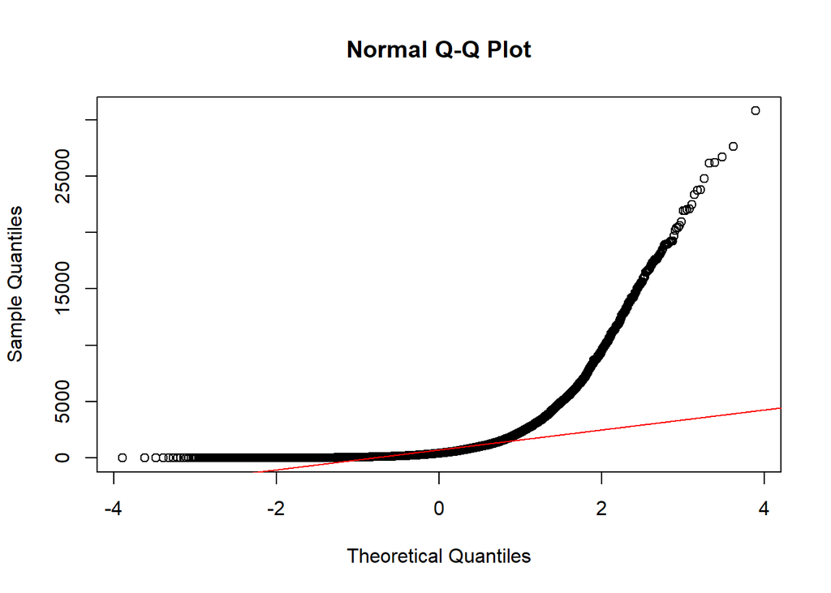

```
##
##  Asymptotic two-sample Kolmogorov-Smirnov test
##
## data:  movies$voteCount and rnorm(nrow(movies), mean(movies$voteCount), sd(movies$voteCount))
## D = 0.2958, p-value < 2.2e-16
## alternative hypothesis: two-sided
```

```
##
##  Lilliefors (Kolmogorov-Smirnov) normality test
##
## data:  movies$voteCount
## D = 0.30045, p-value < 2.2e-16
```

### Prueba de normalidad para **genresAmount**.

Se realizó un histograma para la variable

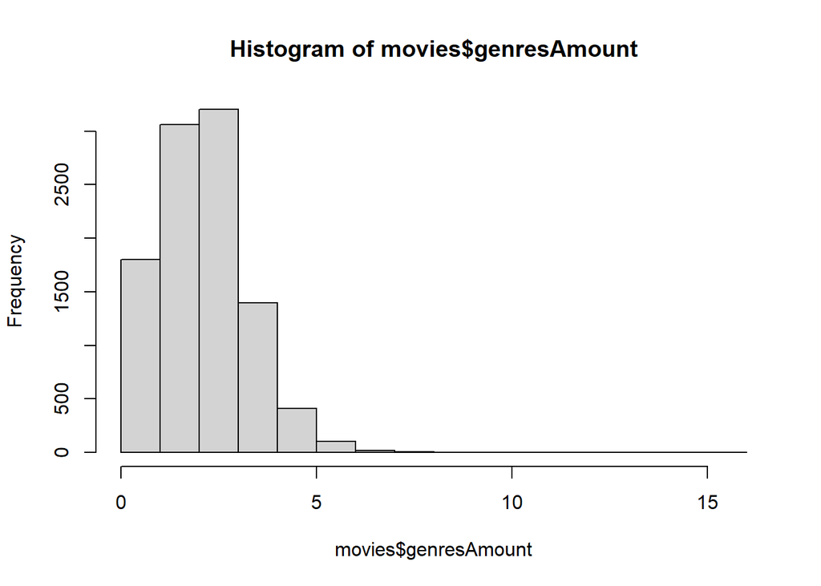

Se puede observar en el histograma que existe un sesgo hacia la derecha de la distribución de la variable. No parece ser una distribución normal.

A continuación se realizó un QQplot para observar la distribución de los valores de genresAmount.

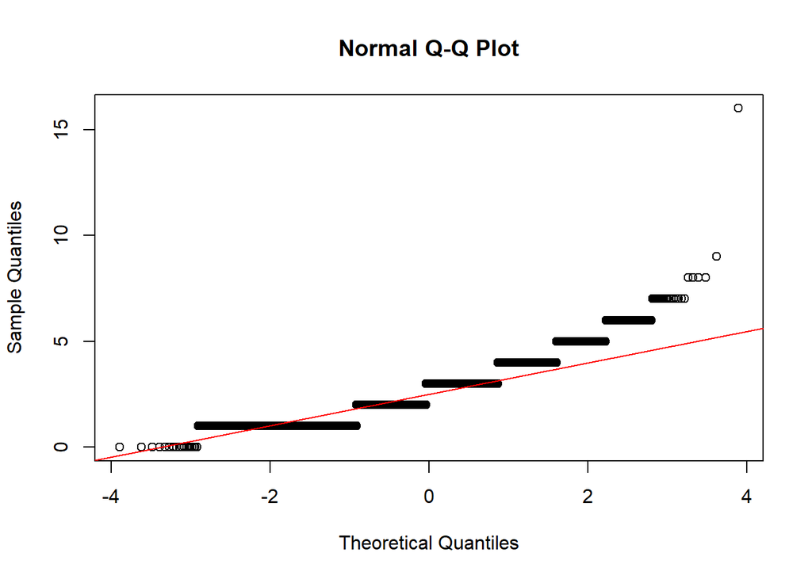

Es posible observar que la distribución de la variable se da en una especie de gradas. No se acerca a la línea teórica, por lo que no parece ser normal.

Luego se realizó la prueba de Lilliefors.

```
##
##  Lilliefors (Kolmogorov-Smirnov) normality test
##
## data:  movies$genresAmount
## D = 0.1836, p-value < 2.2e-16
```

Por medio del valor p se puede confirmar que la distribución de los datos no es normal, debido a que es menor a la significancia.

### Prueba de normalidad para **productionCoAmount**.

Inicialmente se realizó un histograma para observar la distribución de los datos.

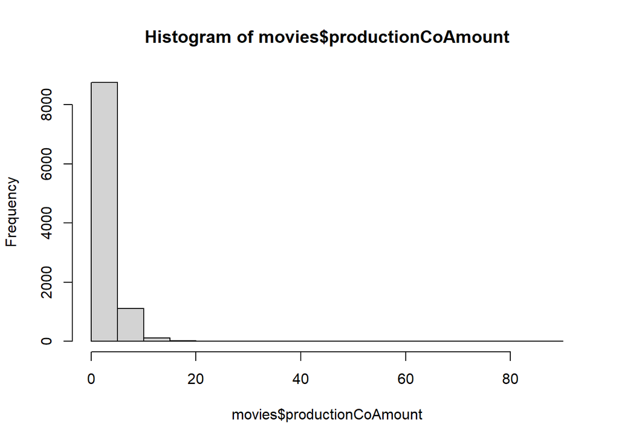

Visualmente en el histograma, los datos no siguen una distribución normal. Tienen un sesgo hacia la derecha.

A continuación se realizó un QQplot para observar la distribución de los valores de productionCoAmount.

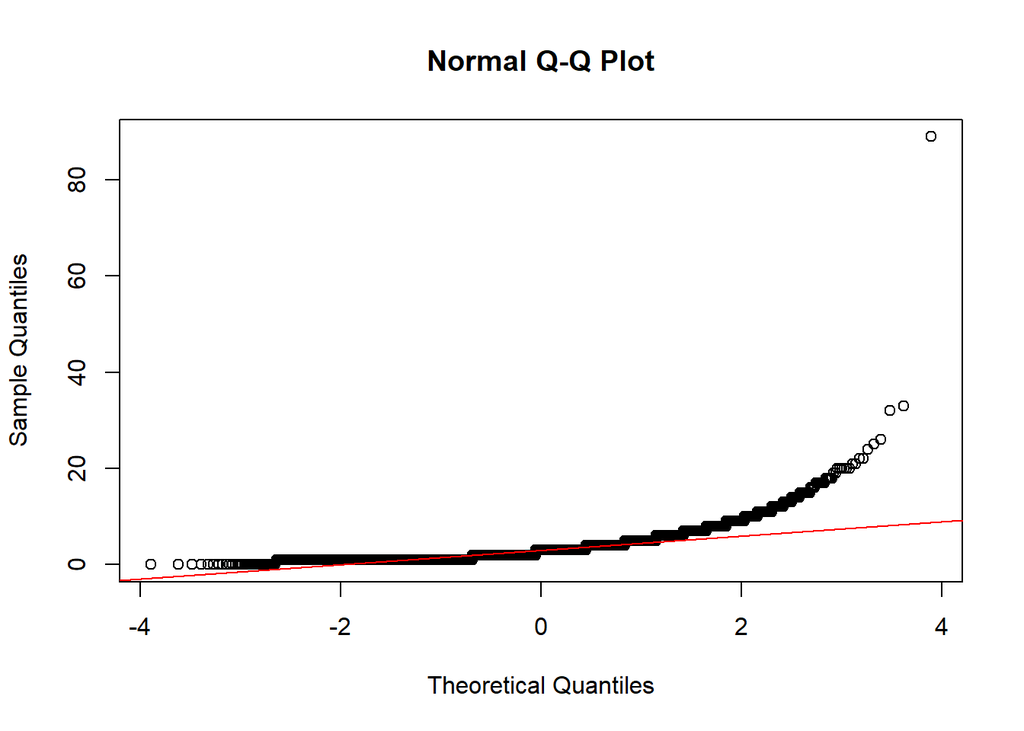

Es posible observar que la distribución de los valores se alejan de la dsitribución teórica, principalmente en los extremos. La distribución no es normal.

Se realizó la prueba de Lilliefors para determinar si hay normalidad.

```
##
##  Lilliefors (Kolmogorov-Smirnov) normality test
##
## data:  movies$productionCoAmount
## D = 0.2004, p-value < 2.2e-16
```

El valor p de la prueba es menor al nivel de significancia, lo cual permite rechazar la hipótesis de que la variable tiene una distribución normal.

### Prueba de normalidad para **productionCountriesAmount**.

Se realizó un histograma para ver la distribución de la variable.

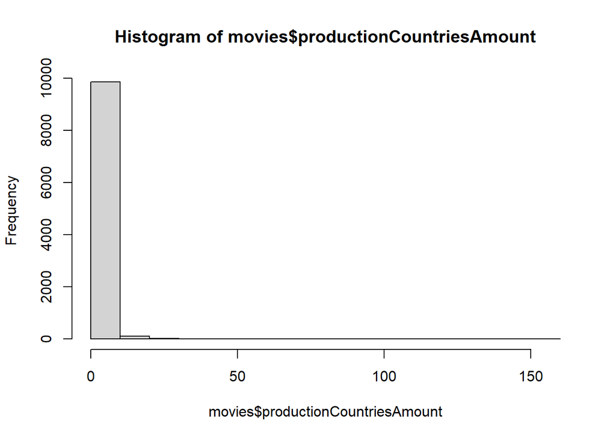

Por medio del histograma se puede ver que la distribución de los datos probablemente no es normal, porque hay una gran concentración de datos del lado izquierdo.

A continuación se realizó un QQplot para observar la distribución de los valores de productionCountriesAmount.

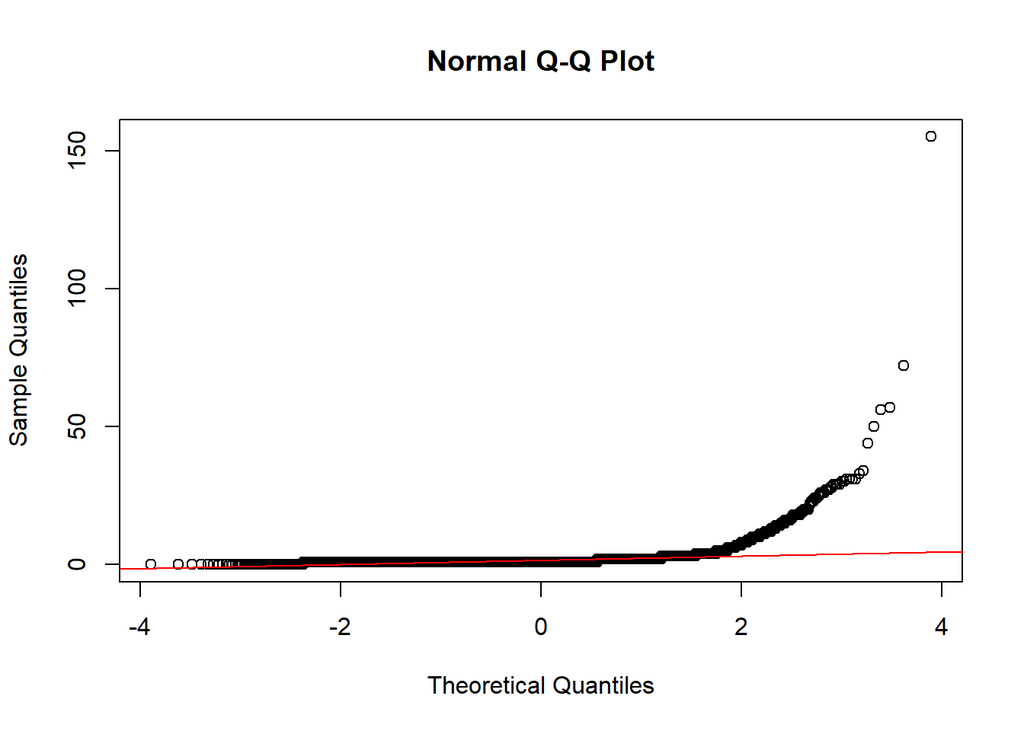

Es posible observar que la distribución de los valores se alejan de la dsitribución teórica, principalmente en el extremo derecho.

Se realizó la prueba de Lilliefors para determinar si hay normalidad.

```
##
##  Lilliefors (Kolmogorov-Smirnov) normality test
##
## data:  movies$productionCountriesAmount
## D = 0.39265, p-value < 2.2e-16
```

El valor p es demasiado bajo, por lo que es posible rechazar la hipótesis de que la distribución es normal.

### Prueba de normalidad para **actorsAmount**.

Se realizó un histograma para ver la distribución de la variable.

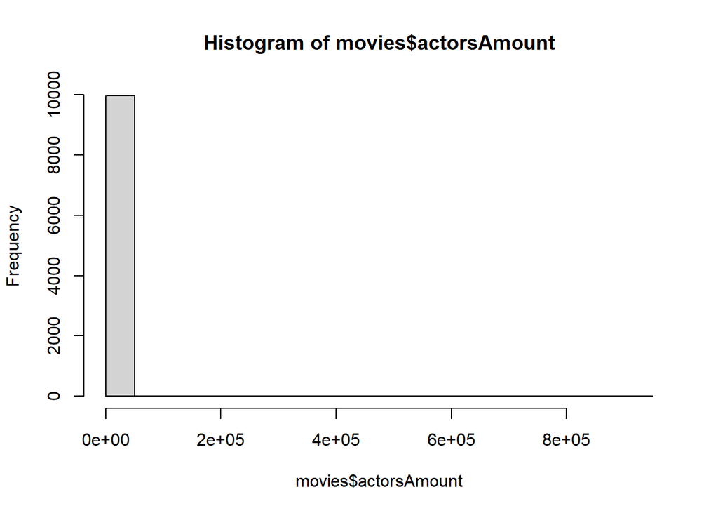

Por medio del histograma se puede ver que la distribución de los datos probablemente no es normal, porque hay una gran concentración de datos del lado izquierdo.

A continuación se realizó un QQplot para observar la distribución de los valores de actorsAmount.

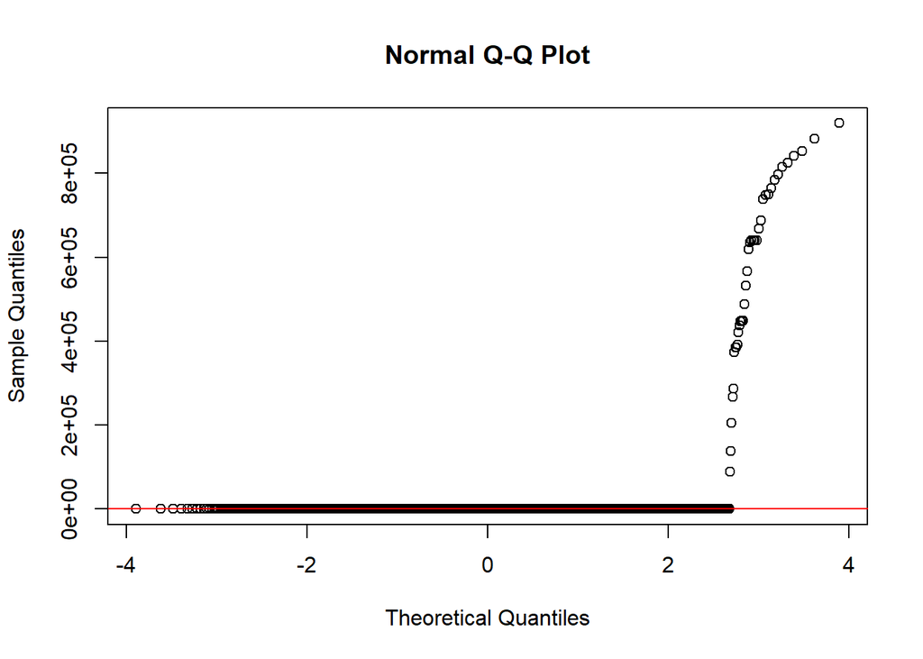

En el extremo derecho hay muchos valores que no se ajustan a la distribución teórica, por lo que se continúa teniendo la hipótesis de que la distribución no es normal.

Se realizó la prueba de Lilliefors para determinar si hay normalidad.

```
##
##  Lilliefors (Kolmogorov-Smirnov) normality test
##
## data:  movies$actorsAmount
## D = 0.51669, p-value < 2.2e-16
```

Al ver que el valor p es demasiado bajo, es posible rechazar la hipótesis de que la distribución es normal.

### Prueba de normalidad para **castWomenAmount**.

A continuación se realizó un QQplot para observar la distribución de los valores de castWomenAmount.

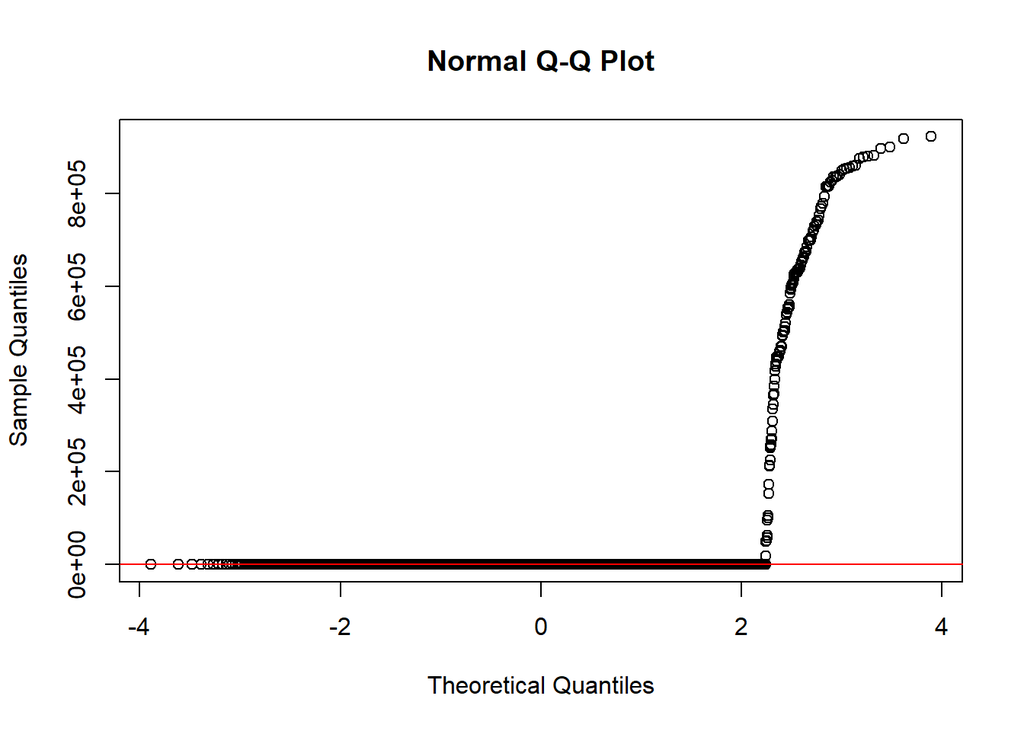

Es posible observar que los valores en la variable en el extremo derecho se alejan significativamente de la línea teórica.

Luego se realizó la prueba de normalidad de Lilliefors.

```
##
##  Lilliefors (Kolmogorov-Smirnov) normality test
##
## data:  castWomen
## D = 0.52831, p-value < 2.2e-16
```

La cantidad de mujeres en las películas no sigue una distribución normal, porque el valor de p es más bajo que el nivel de significancia.

### Prueba de normalidad para **castMenAmount**.

A continuación se realizó un QQplot para observar la distribución de los valores de castMenAmount.

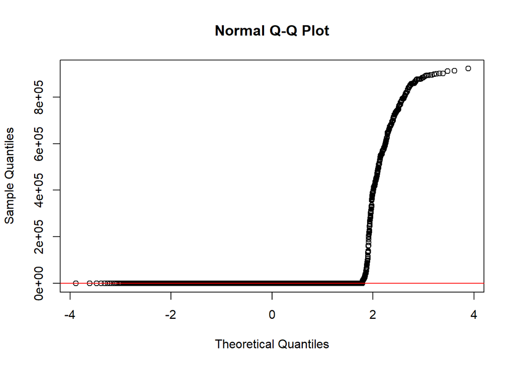

Es posible observar que los valores en la variable en el extremo derecho se alejan significativamente de la línea teórica.

Luego se realizó la prueba de normalidad de Lilliefors.

```
##
##  Lilliefors (Kolmogorov-Smirnov) normality test
##
## data:  castMen
## D = 0.52814, p-value < 2.2e-16
```

La cantidad de hombres en las películas no sigue una distribución normal, porque el valor de p es más bajo que el nivel de significancia.

### Tablas de frecuencias para variables cualitativas

A continuación se muestra la frecuencia de películas que tienen **homePage** y las que no.

```
##
## FALSE  TRUE
##  4193  5807
```

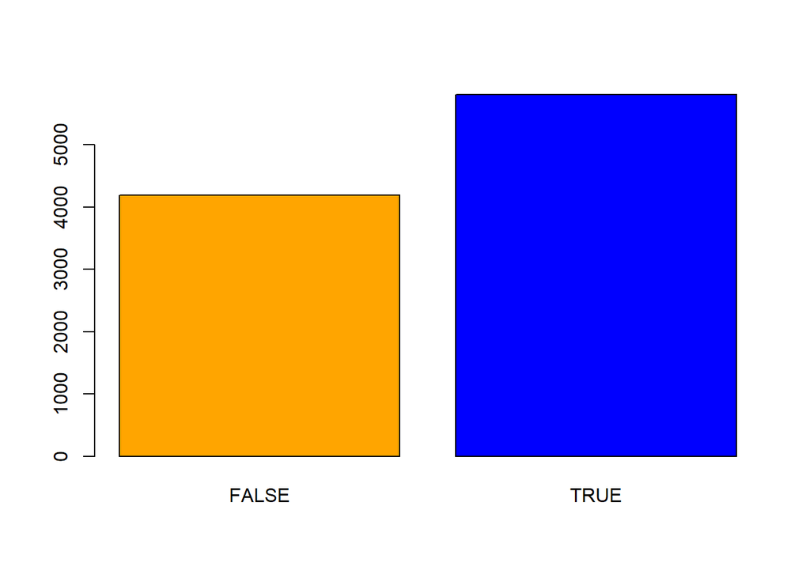

A continuación se muestra la frecuencia de películas que tienen **video** y las que no.

```
##
## FALSE  TRUE
##  9514   486
```

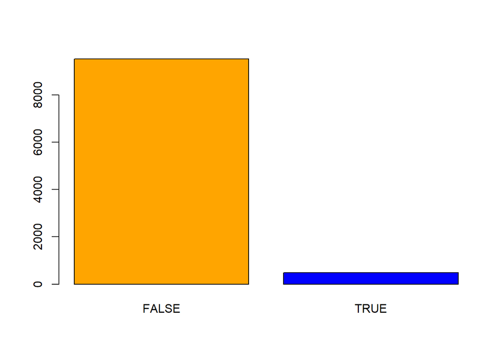

A continuación se muestra la frecuencia del **lenguaje original** de las películas.

```
##
##   ar   bn   ca   cn   cs   da   de   el   en   es   eu   fa   fi   fr   he   hi
##    1    1    1   80    2   27   84    2 7772  425    1    3    8  271    1   27
##   id   is   it   ja   ko   la   ml   ms   nb   nl   no   pl   pt   ro   ru   sr
##   12    4  100  644  167    1    1    1    1   18   28   15   43    2   67    4
##   sv   ta   te   th   tl   tr   uk   zh
##   27    1    5   17    5   10    2  119
```

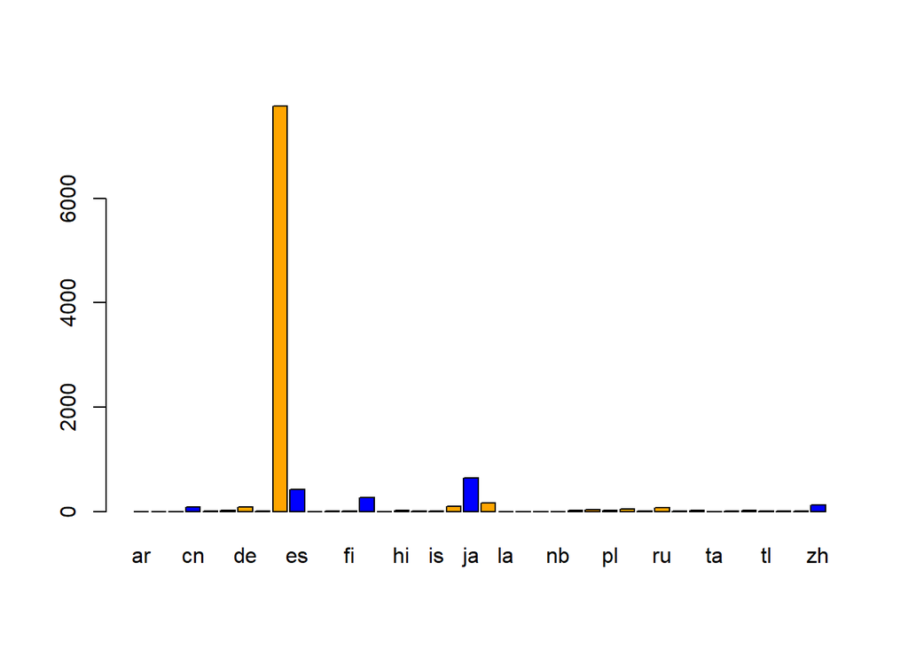

Finalmente se muestra la cantidad de películas por año.

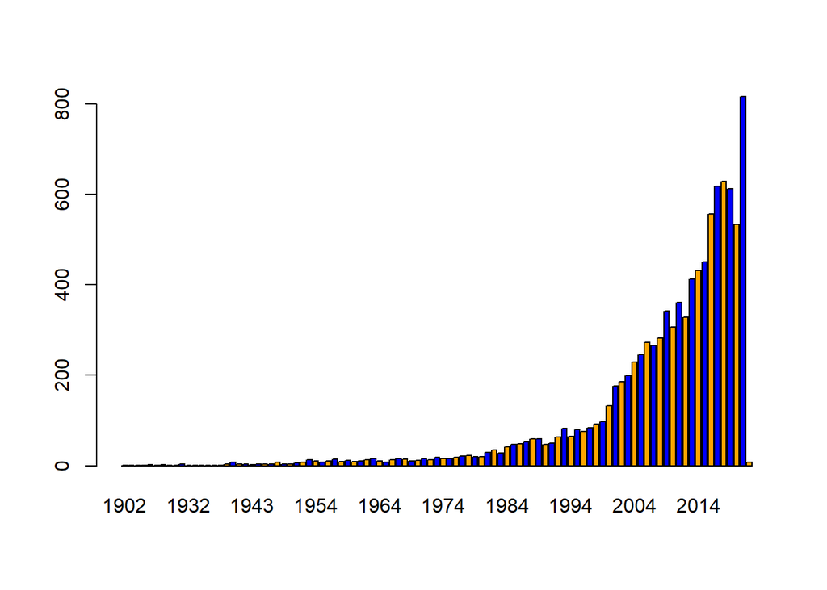

También se muestra por mes.

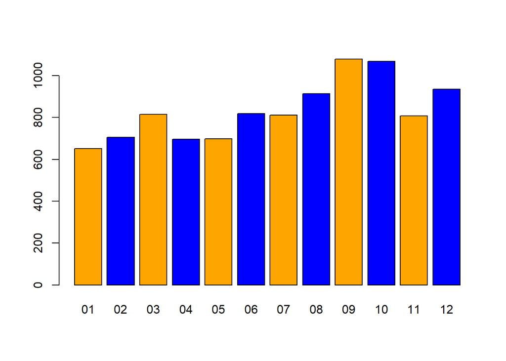

## 4. Preguntas importantes del dataset.

### 4.1 ¿Cuáles son las 10 películas que contaron con más presupuesto?

Las 10 películas que tuvieron mayor presupuesto se muestran a continuación  
mostrando también su presupuesto respectivo.

```
##                                            title    budget
## 717  Pirates of the Caribbean: On Stranger Tides 380000000
## 4711                     Avengers: Age of Ultron 365000000
## 5953                           Avengers: Endgame 356000000
## 164     Pirates of the Caribbean: At World's End 300000000
## 4954                              Justice League 300000000
## 5954                      Avengers: Infinity War 300000000
## 608                             Superman Returns 270000000
## 3792                                     Tangled 260000000
## 7135                               The Lion King 260000000
## 281                                 Spider-Man 3 258000000
```

[figure not shown]

### 4.2 ¿Cuáles son las 10 películas que más ingresos tuvieron?

Las 10 películas que tuvieron más ingresos, con su cantidad respectiva, se  
muestran a continuación.

```
##                             title    revenue
## 3211                       Avatar 2847246203
## 5953            Avengers: Endgame 2797800564
## 308                       Titanic 2187463944
## 4948 Star Wars: The Force Awakens 2068223624
## 5954       Avengers: Infinity War 2046239637
## 4915               Jurassic World 1671713208
## 7135                The Lion King 1667635327
## 9050      Spider-Man: No Way Home 1631853496
## 3398                 The Avengers 1518815515
## 5088                    Furious 7 1515047671
```

### 4.3 ¿Cuál es la película que más votos tuvo?

La película que más votos tuvo se muestra a continuación

```
##          title voteCount
## 3512 Inception     30788
```

[output not shown]

## OTRO 4.6

```r
ordered <- movies[order(movies$runtime, decreasing=T),]
firstTwentyMovies <- ordered[1:20,]
genres20 <- vapply(strsplit(firstTwentyMovies[, c("genres")], split="|", fixed = T), '[', 1, FUN.VALUE = character(1))

unique(genres20)
```

```
## [1] "Documentary" "Drama"       "Action"      "Crime"       "Music"
## [6] "War"         "Comedy"
```

```r
genres <- vapply(strsplit(movies[, c("genres")], split="|", fixed = T), '[', 1, FUN.VALUE = character(1))

table <- table(genres)
names(table[which.max(table)])
```

```
## [1] "Drama"
```

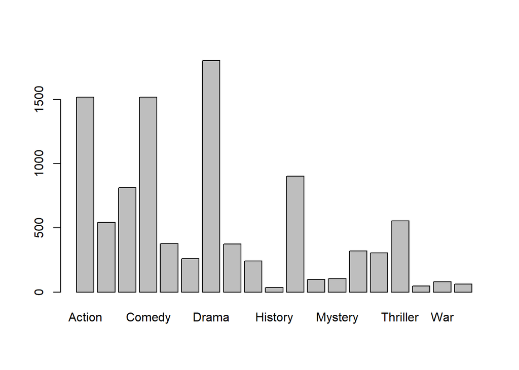

```r
barplot(table)
```

## 4.12

```r
months <- strtoi(format(as.POSIXct(movies$releaseDate), "%m"))
chisq.test(months, movies$revenue)
```

```
##
##  Pearson's Chi-squared test
##
## data:  months and movies$revenue
## X-squared = 36890, df = 36756, p-value = 0.3094
```

## 4.14

```r
cor(movies$voteAvg, movies$popularity)
```

```
## [1] 0.06643627
```

```r
cor(movies$popularity, movies$revenue)
```

```
## [1] 0.1625461
```

```r
cor(movies$voteAvg, movies$revenue)
```

```
## [1] 0.1412618
```

## 4.11

```r
cor(movies$budget, movies$revenue)
```

```
## [1] 0.757454
```

## Preguntas extra

### ¿La cantidad de géneros a la que pertenece una películas influye en su popularidad y sus ganancias?

### Correlación entre popularidad y cantidad de géneros.

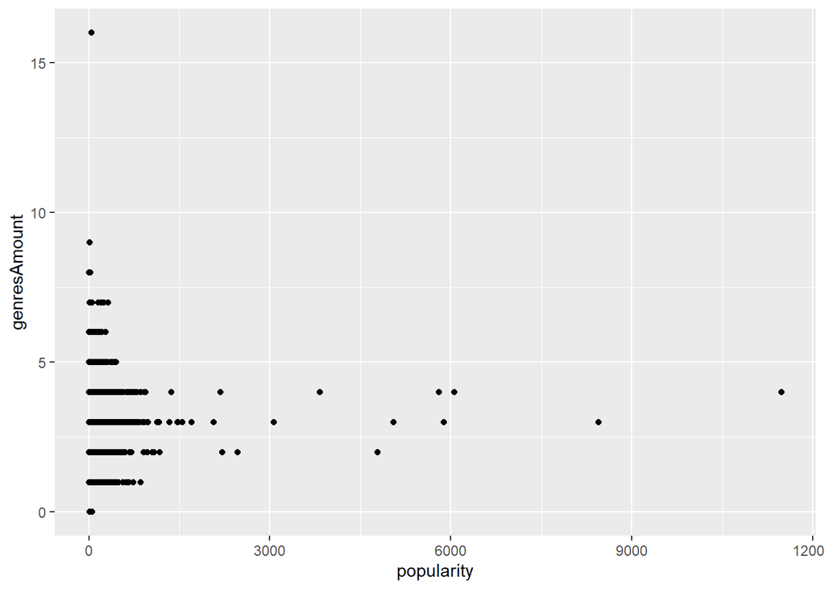

```
##              popularity genresAmount
## popularity   1.00000000   0.03916933
## genresAmount 0.03916933   1.00000000
```

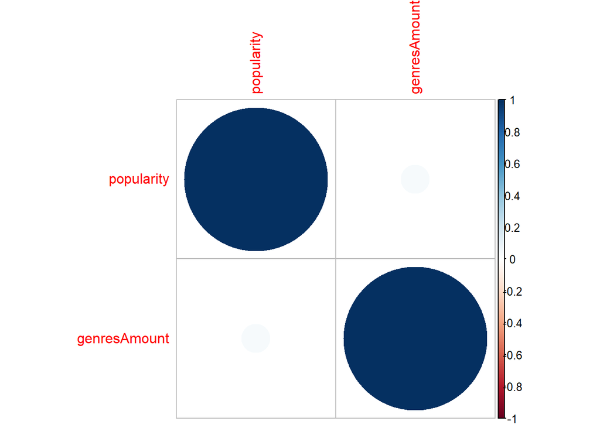

Al observar el gráfico de dispersión se evidencia que no existen una relación entre las variables. Además, al hacer el gráfico de correlación, igualmente se muestra que no existe correlación. Siendo el valor de R^2 0.03, se confirma que la popularidad de una película no depende de la cantidad de géneros a la que pertenece.

### Correlación entre ingresos y cantidad de géneros.

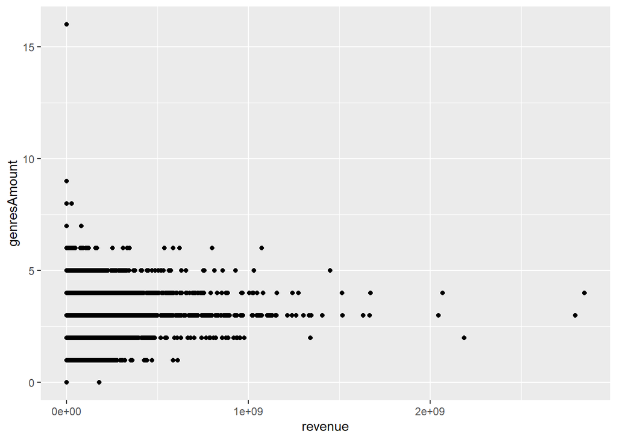

```
##                revenue genresAmount
## revenue      1.0000000    0.1362282
## genresAmount 0.1362282    1.0000000
```

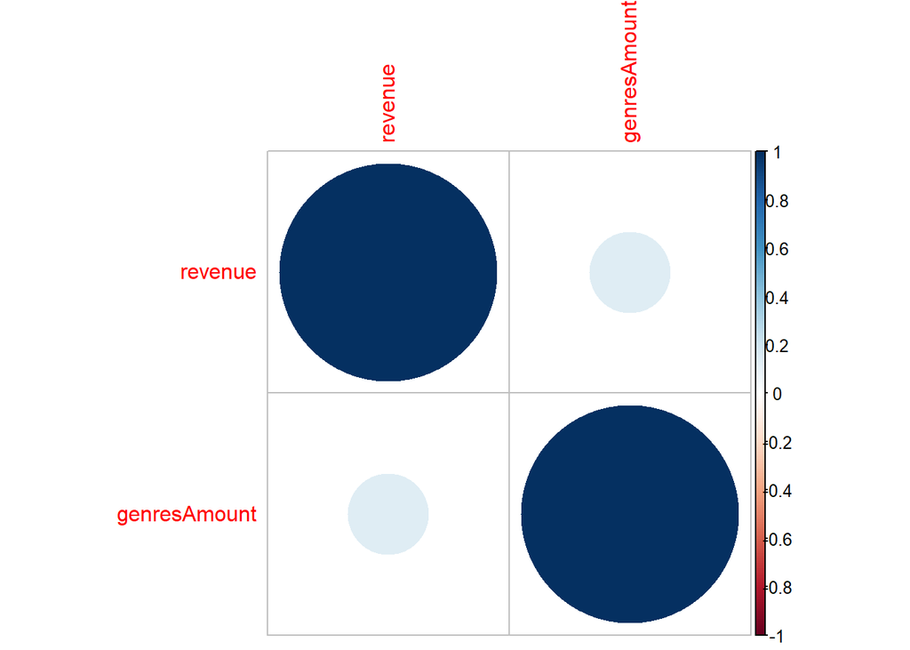

Al observar el gráfico de dispersión se evidencia que no existen una relación entre las variables. Al hacer el gráfico de correlación se muestra una ligera relación, sin embargo, no es lo suficientemente grande para indicar que los ingresos dependen de la cantidad de géneros. Siendo el valor de R^2 0.14, se confirma que los ingresos de una película no dependen de la cantidad de géneros a la que pertenece.

### ¿Cuál es la correlación entre la cantidad de compañías y la popularidad de una película?

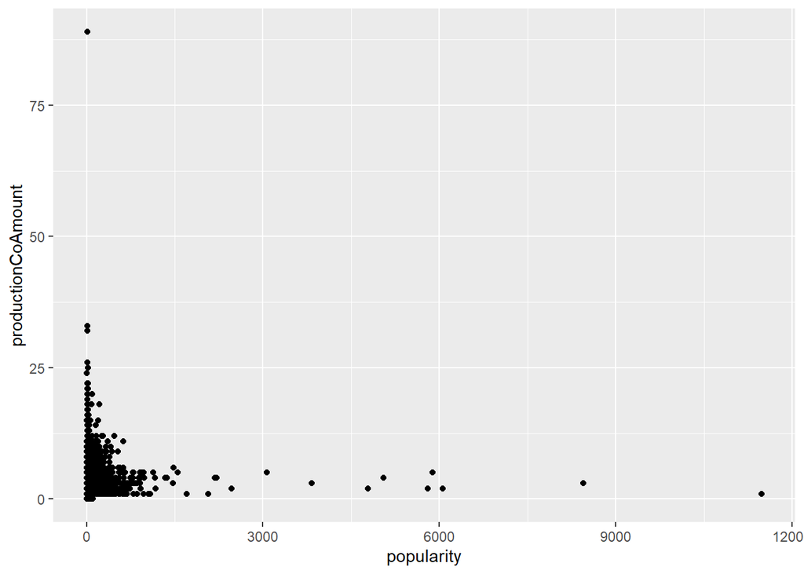

```
##                     popularity productionCoAmount
## popularity         1.000000000        0.005712254
## productionCoAmount 0.005712254        1.000000000
```

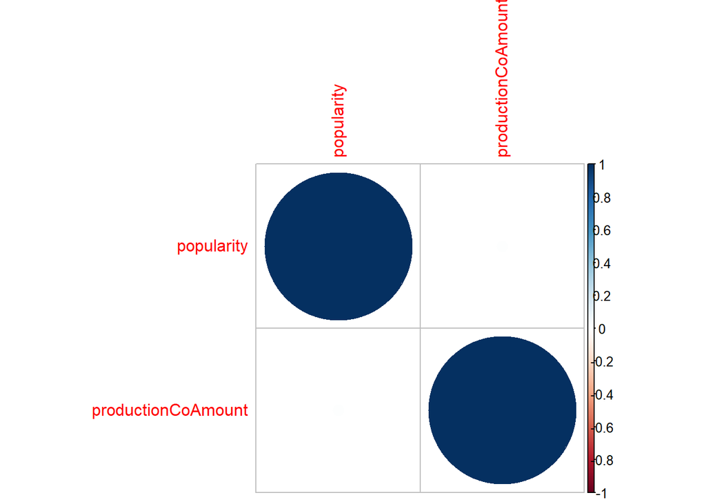

Como se observa en el gráfico de dispersión, existen datos que no parecen estar relacionados entre sí. Además, el gráfico de correlación muestra que no existe relación entre las variables, confirmado por el valor de R^2 de 0.005. Entonces, la cantidad de compañías productoras no afecta la popularidad de la película.

### ¿El ingreso de una película tiene relación con la presencia de un vídeo promocional de esta?

```r
videoAsNumeric <- as.numeric(movies$hasVideo)

cor.test(movies$revenue, videoAsNumeric)
```

```
##
##  Pearson's product-moment correlation
##
## data:  movies$revenue and videoAsNumeric
## t = 20.64, df = 9998, p-value < 2.2e-16
## alternative hypothesis: true correlation is not equal to 0
## 95 percent confidence interval:
##  0.1832853 0.2208840
## sample estimates:
##       cor
## 0.2021592
```

El índice de correlación es bajo entre ambas variables, por lo tanto se puede indicar que la presencia de un video promocional tiene poca influencia en los ingresos de una película.

### ¿Cómo se comporta el revenue de una película según su lenguaje?

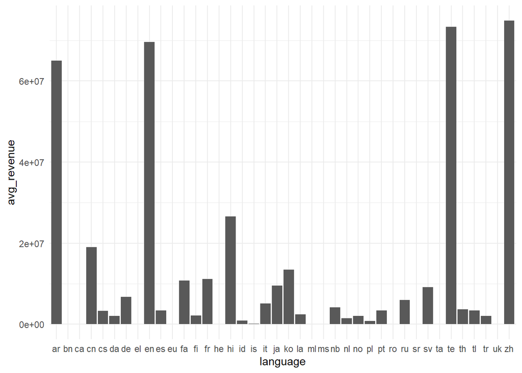